# Predicting Spotify Song Popularity Using Data Science and Machine Learning

**Author:** Aya Abdine

## Project Overview

Music streaming platforms generate large amounts of data describing both songs and listener engagement. This project investigates whether measurable audio characteristics can help explain and predict the popularity of songs on Spotify.

Using a large historical dataset of Spotify tracks, the analysis explores relationships between song popularity and audio features such as danceability, energy, loudness, valence, tempo, acousticness, instrumentalness, liveness, and speechiness.

The project combines exploratory data analysis (EDA) with machine learning to identify important patterns and evaluate how accurately song popularity can be predicted from audio features alone.

## Research Question

**How well do Spotify audio features explain and predict song popularity?**

## Project Objectives

- Explore the structure and quality of the Spotify dataset.
- Analyze the distribution of song popularity.
- Investigate relationships between audio features and popularity.
- Examine how musical characteristics and popularity change over time.
- Build and compare machine learning models for predicting popularity.
- Evaluate model performance using appropriate regression metrics.
- Identify the audio features that contribute most to popularity predictions.
- Discuss the limitations of predicting popularity using audio features alone.

## 1. Setup and Imports

This section imports the Python libraries required for data manipulation, visualization, model training, and model evaluation.

## 2. Data Loading and Initial Inspection

This section loads the Spotify dataset and performs an initial inspection of its structure, dimensions, variables, and data types.

|  | valence | year | acousticness | artists | danceability | duration_ms | energy | explicit | id | instrumentalness | key | liveness | loudness | mode | name | popularity | release_date | speechiness | tempo |
| --- | --- | --- | --- | --- | --- | --- | --- | --- | --- | --- | --- | --- | --- | --- | --- | --- | --- | --- | --- |
| 0 | 0.0594 | 1921 | 0.982 | ['Sergei Rachmaninoff', 'James Levine', 'Berli... | 0.279 | 831667 | 0.211 | 0 | 4BJqT0PrAfrxzMOxytFOIz | 0.878000 | 10 | 0.665 | -20.096 | 1 | Piano Concerto No. 3 in D Minor, Op. 30: III. ... | 4 | 1921 | 0.0366 | 80.954 |
| 1 | 0.9630 | 1921 | 0.732 | ['Dennis Day'] | 0.819 | 180533 | 0.341 | 0 | 7xPhfUan2yNtyFG0cUWkt8 | 0.000000 | 7 | 0.160 | -12.441 | 1 | Clancy Lowered the Boom | 5 | 1921 | 0.4150 | 60.936 |
| 2 | 0.0394 | 1921 | 0.961 | ['KHP Kridhamardawa Karaton Ngayogyakarta Hadi... | 0.328 | 500062 | 0.166 | 0 | 1o6I8BglA6ylDMrIELygv1 | 0.913000 | 3 | 0.101 | -14.850 | 1 | Gati Bali | 5 | 1921 | 0.0339 | 110.339 |
| 3 | 0.1650 | 1921 | 0.967 | ['Frank Parker'] | 0.275 | 210000 | 0.309 | 0 | 3ftBPsC5vPBKxYSee08FDH | 0.000028 | 5 | 0.381 | -9.316 | 1 | Danny Boy | 3 | 1921 | 0.0354 | 100.109 |
| 4 | 0.2530 | 1921 | 0.957 | ['Phil Regan'] | 0.418 | 166693 | 0.193 | 0 | 4d6HGyGT8e121BsdKmw9v6 | 0.000002 | 3 | 0.229 | -10.096 | 1 | When Irish Eyes Are Smiling | 2 | 1921 | 0.0380 | 101.665 |

```
Dataset shape: (170653, 19)

Column names:
['valence', 'year', 'acousticness', 'artists', 'danceability', 'duration_ms', 'energy', 'explicit', 'id', 'instrumentalness', 'key', 'liveness', 'loudness', 'mode', 'name', 'popularity', 'release_date', 'speechiness', 'tempo']

Dataset information:
<class 'pandas.core.frame.DataFrame'>
RangeIndex: 170653 entries, 0 to 170652
Data columns (total 19 columns):
 #   Column            Non-Null Count   Dtype
---  ------            --------------   -----
 0   valence           170653 non-null  float64
 1   year              170653 non-null  int64
 2   acousticness      170653 non-null  float64
 3   artists           170653 non-null  object
 4   danceability      170653 non-null  float64
 5   duration_ms       170653 non-null  int64
 6   energy            170653 non-null  float64
 7   explicit          170653 non-null  int64
 8   id                170653 non-null  object
 9   instrumentalness  170653 non-null  float64
 10  key               170653 non-null  int64
 11  liveness          170653 non-null  float64
 12  loudness          170653 non-null  float64
 13  mode              170653 non-null  int64
 14  name              170653 non-null  object
 15  popularity        170653 non-null  int64
 16  release_date      170653 non-null  object
 17  speechiness       170653 non-null  float64
 18  tempo             170653 non-null  float64
dtypes: float64(9), int64(6), object(4)
memory usage: 24.7+ MB
```

## 3. Data Quality Assessment

Before preprocessing, the dataset is assessed for missing values and duplicate records. This helps determine which cleaning steps are actually necessary rather than removing observations without evidence.

```
Missing values by column:
valence             0
year                0
acousticness        0
artists             0
danceability        0
duration_ms         0
energy              0
explicit            0
id                  0
instrumentalness    0
key                 0
liveness            0
loudness            0
mode                0
name                0
popularity          0
release_date        0
speechiness         0
tempo               0
dtype: int64

Number of duplicate rows: 0
```

## 4. Descriptive Statistics

This section examines the distributions and ranges of the numerical variables to identify unusual values and better understand the characteristics of the dataset before further analysis.

|  | count | mean | std | min | 25% | 50% | 75% | max |
| --- | --- | --- | --- | --- | --- | --- | --- | --- |
| valence | 170653.0 | 0.528587 | 0.263171 | 0.0 | 0.3170 | 0.540000 | 0.7470 | 1.000 |
| year | 170653.0 | 1976.787241 | 25.917853 | 1921.0 | 1956.0000 | 1977.000000 | 1999.0000 | 2020.000 |
| acousticness | 170653.0 | 0.502115 | 0.376032 | 0.0 | 0.1020 | 0.516000 | 0.8930 | 0.996 |
| danceability | 170653.0 | 0.537396 | 0.176138 | 0.0 | 0.4150 | 0.548000 | 0.6680 | 0.988 |
| duration_ms | 170653.0 | 230948.310666 | 126118.414668 | 5108.0 | 169827.0000 | 207467.000000 | 262400.0000 | 5403500.000 |
| energy | 170653.0 | 0.482389 | 0.267646 | 0.0 | 0.2550 | 0.471000 | 0.7030 | 1.000 |
| explicit | 170653.0 | 0.084575 | 0.278249 | 0.0 | 0.0000 | 0.000000 | 0.0000 | 1.000 |
| instrumentalness | 170653.0 | 0.167010 | 0.313475 | 0.0 | 0.0000 | 0.000216 | 0.1020 | 1.000 |
| key | 170653.0 | 5.199844 | 3.515094 | 0.0 | 2.0000 | 5.000000 | 8.0000 | 11.000 |
| liveness | 170653.0 | 0.205839 | 0.174805 | 0.0 | 0.0988 | 0.136000 | 0.2610 | 1.000 |
| loudness | 170653.0 | -11.467990 | 5.697943 | -60.0 | -14.6150 | -10.580000 | -7.1830 | 3.855 |
| mode | 170653.0 | 0.706902 | 0.455184 | 0.0 | 0.0000 | 1.000000 | 1.0000 | 1.000 |
| popularity | 170653.0 | 31.431794 | 21.826615 | 0.0 | 11.0000 | 33.000000 | 48.0000 | 100.000 |
| speechiness | 170653.0 | 0.098393 | 0.162740 | 0.0 | 0.0349 | 0.045000 | 0.0756 | 0.970 |
| tempo | 170653.0 | 116.861590 | 30.708533 | 0.0 | 93.4210 | 114.729000 | 135.5370 | 243.507 |

## 5. Investigation of Unusual Values

The descriptive statistics reveal several extreme or boundary values. Before applying any filtering, these observations are examined to determine whether they represent genuine tracks or potential data-quality issues.

|  | name | artists | year | duration_min | popularity |
| --- | --- | --- | --- | --- | --- |
| 107341 | Brown Noise - 90 Minutes | ['Sound Dreamer'] | 2013 | 90.058333 | 50 |
| 138618 | Brown Noise for Sleep | ['Sounds for Life'] | 2009 | 71.167233 | 42 |
| 168377 | Midnight Thunderstorm Part 2 | ['Lightning, Thunder and Rain Storm'] | 2009 | 71.156783 | 43 |
| 55239 | Ocean Waves for Sleep | ['Ocean Waves For Sleep'] | 2010 | 68.670967 | 56 |
| 106689 | Natural White Noise for Babies - Ocean Waves f... | ['One Hour Gulf Coast Ocean Waves'] | 2010 | 68.670967 | 57 |
| 137403 | Dopesmoker | ['Sleep'] | 2003 | 63.606217 | 42 |
| 68058 | Thursday Afternoon - 2005 Digital Remaster | ['Brian Eno'] | 1985 | 60.846667 | 39 |
| 42597 | Raba El Adawya Pt. 2 | ['Umm Kulthum'] | 1946 | 59.498883 | 0 |
| 160506 | The Psychologically Ultimate Seashore (16 rpm) | ['Environments'] | 1969 | 59.299250 | 19 |
| 93949 | Raba El Adawya Pt. 1 | ['Umm Kulthum'] | 1946 | 59.281117 | 0 |

```
instrumentalness    46580
valence               196
tempo                 143
danceability          143
speechiness           143
acousticness           20
liveness               12
energy                  9
dtype: int64
```

```
Minimum                           0.000000
Maximum                         100.000000
Mean                             31.431794
Median                           33.000000
Zero popularity tracks        27892.000000
Zero popularity percentage       16.344278
dtype: float64
```

## 6. Exploratory Data Analysis

### 6.1 Distribution of Song Popularity

The distribution of the target variable is examined to understand how Spotify popularity scores are spread across tracks. Particular attention is given to the concentration of zero-popularity tracks and the overall shape of the distribution.

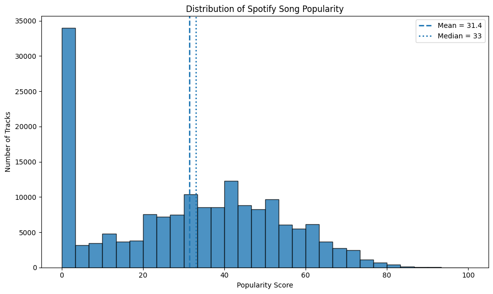

**Finding:** The popularity distribution shows a pronounced concentration at the lowest end of the scale. A total of 27,892 tracks (16.34% of the dataset) have a popularity score of exactly 0. Beyond this concentration, most popularity scores fall within the low-to-moderate range, while very high popularity scores are relatively uncommon. The mean popularity score is 31.4 and the median is 33. Overall, the distribution is not well described as simply right-skewed because of the substantial mass at zero and the broader concentration of non-zero scores across the middle of the scale.

### 6.2 Popularity Over Time

This section examines how average song popularity varies by release year. Because the dataset spans from 1921 to 2020, the analysis helps identify long-term temporal patterns in Spotify popularity scores.

|  | year | mean | median | count |
| --- | --- | --- | --- | --- |
| 0 | 1921 | 0.653333 | 0.0 | 150 |
| 1 | 1922 | 0.140845 | 0.0 | 71 |
| 2 | 1923 | 5.389189 | 4.0 | 185 |
| 3 | 1924 | 0.661017 | 0.0 | 236 |
| 4 | 1925 | 2.604317 | 0.0 | 278 |

|  | year | count |
| --- | --- | --- |
| 1 | 1922 | 71 |
| 0 | 1921 | 150 |
| 2 | 1923 | 185 |
| 3 | 1924 | 236 |
| 4 | 1925 | 278 |
| 11 | 1932 | 502 |
| 13 | 1934 | 578 |
| 17 | 1938 | 613 |
| 6 | 1927 | 615 |
| 16 | 1937 | 657 |

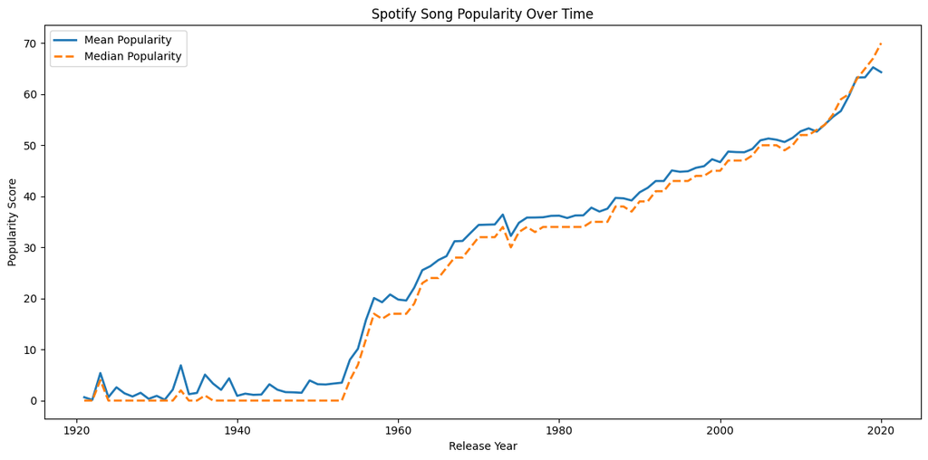

**Finding:** Average and median popularity scores show a strong upward pattern across release years. Tracks from earlier decades generally have much lower popularity scores, while more recently released tracks tend to receive substantially higher scores. The close movement of the yearly mean and median suggests that this pattern is not driven solely by a small number of highly popular tracks. However, the trend should not be interpreted as evidence that songs inherently became more popular over time. Spotify popularity reflects platform-specific and time-sensitive listening behavior, and the dataset contains unequal numbers of tracks across release years. Recency effects, catalog representation, and current user engagement may therefore contribute to the observed relationship.

### 6.3 Relationship Between Release Year and Popularity

The strong temporal pattern observed above suggests that release year may be an important predictor of popularity. This section quantifies the strength of that relationship using correlation analysis.

|  | year | popularity |
| --- | --- | --- |
| year | 1.000000 | 0.862442 |
| popularity | 0.862442 | 1.000000 |

**Finding:** Release year has a strong positive correlation with popularity (`r = 0.862`). This indicates that more recently released tracks tend to have substantially higher popularity scores in this dataset. However, the relationship should not be interpreted as causal. Because Spotify popularity reflects current platform engagement, the strong association may partly capture recency effects, differences in catalog representation, and changing listening behavior over time. For this reason, later predictive models will compare an audio-feature-only specification with a second specification that also includes release year.

### 6.4 Audio Features and Popularity

This section examines the relationships between Spotify audio characteristics and song popularity. Correlation analysis is used as an initial exploratory step to identify which numerical audio features show the strongest linear associations with popularity.

```
energy              0.485005
loudness            0.457051
danceability        0.199606
tempo               0.133310
valence             0.014200
liveness           -0.076464
speechiness        -0.171979
instrumentalness   -0.296750
acousticness       -0.573162
Name: popularity, dtype: float64
```

### 6.5 Audio Features After Accounting for Release Year

Because release year is strongly associated with popularity, raw correlations between audio features and popularity may partly reflect temporal changes in music characteristics. To examine this issue, popularity is first adjusted for its linear relationship with release year, and audio-feature correlations are then recalculated using the resulting residuals.

```
valence             0.076182
danceability        0.073144
loudness            0.071994
energy              0.054680
tempo               0.023045
liveness           -0.053403
speechiness        -0.053832
acousticness       -0.085758
instrumentalness   -0.122188
dtype: float64
```

**Finding:** The relationships between audio features and popularity weaken substantially after accounting for the linear effect of release year. For example, the correlation for energy decreases from `r = 0.485` to `r = 0.055`, loudness from `r = 0.457` to `r = 0.072`, and acousticness from `r = -0.573` to `r = -0.086`. Instrumentalness shows the strongest remaining negative association (`r = -0.122`), although this relationship is still weak. Overall, these results suggest that much of the strong raw association between audio characteristics and popularity is linked to temporal structure in the dataset. Audio features alone appear to have limited linear relationships with popularity once the release-year trend is partially accounted for.

### 6.6 Raw vs Year-Adjusted Audio Feature Correlations

To assess how strongly temporal structure influences the observed relationships, raw audio-feature correlations with popularity are compared with correlations calculated after removing the linear relationship between release year and popularity.

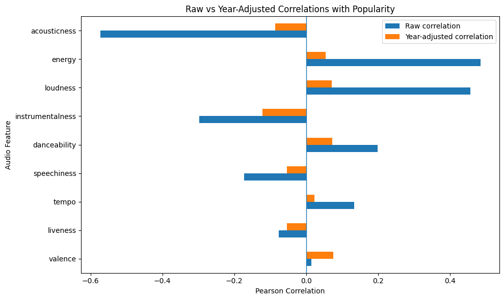

**Finding:** The comparison reveals a substantial reduction in most audio-feature correlations after accounting for the linear relationship between release year and popularity. The strongest raw associations—particularly for acousticness, energy, and loudness—shrink markedly in the year-adjusted analysis. This indicates that temporal structure explains a considerable portion of the relationships observed in the raw data. After adjustment, all remaining correlations are weak, suggesting that individual audio features have limited linear associations with popularity beyond the release-year pattern captured here.

### 6.7 Correlations Among Audio Features

Before predictive modeling, relationships among the audio features are examined to identify strongly correlated predictors. High correlations between predictors can complicate coefficient interpretation in linear models and indicate overlapping information.

|  | acousticness | danceability | energy | instrumentalness | liveness | loudness | speechiness | tempo | valence |
| --- | --- | --- | --- | --- | --- | --- | --- | --- | --- |
| acousticness | 1.00 | -0.27 | -0.75 | 0.33 | -0.02 | -0.56 | -0.04 | -0.21 | -0.18 |
| danceability | -0.27 | 1.00 | 0.22 | -0.28 | -0.10 | 0.29 | 0.24 | 0.00 | 0.56 |
| energy | -0.75 | 0.22 | 1.00 | -0.28 | 0.13 | 0.78 | -0.07 | 0.25 | 0.35 |
| instrumentalness | 0.33 | -0.28 | -0.28 | 1.00 | -0.05 | -0.41 | -0.12 | -0.11 | -0.20 |
| liveness | -0.02 | -0.10 | 0.13 | -0.05 | 1.00 | 0.06 | 0.13 | 0.01 | 0.00 |
| loudness | -0.56 | 0.29 | 0.78 | -0.41 | 0.06 | 1.00 | -0.14 | 0.21 | 0.31 |
| speechiness | -0.04 | 0.24 | -0.07 | -0.12 | 0.13 | -0.14 | 1.00 | -0.01 | 0.05 |
| tempo | -0.21 | 0.00 | 0.25 | -0.11 | 0.01 | 0.21 | -0.01 | 1.00 | 0.17 |
| valence | -0.18 | 0.56 | 0.35 | -0.20 | 0.00 | 0.31 | 0.05 | 0.17 | 1.00 |

#### Interpretation

Several audio features show substantial correlations with one another. The strongest positive relationship is observed between energy and loudness (r = 0.78), while energy and acousticness exhibit a strong negative relationship (r = -0.75). Danceability and valence are moderately positively correlated (r = 0.56), whereas acousticness and loudness show a moderate negative relationship (r = -0.56).

These patterns indicate that some audio characteristics contain overlapping information. This is particularly relevant for linear regression, where multicollinearity may affect coefficient stability and interpretation. Therefore, multicollinearity will be examined more formally before predictive modeling.

### 6.8 Multicollinearity Assessment

To complement the correlation analysis, Variance Inflation Factors (VIF) are calculated for the numerical predictors. VIF measures how strongly the variance of a regression coefficient is inflated by linear relationships with other predictors.

|  | Feature | VIF |
| --- | --- | --- |
| 0 | energy | 4.92 |
| 1 | loudness | 3.17 |
| 2 | acousticness | 3.01 |
| 3 | year | 2.02 |
| 4 | valence | 1.98 |
| 5 | danceability | 1.93 |
| 6 | instrumentalness | 1.35 |
| 7 | speechiness | 1.28 |
| 8 | tempo | 1.11 |
| 9 | liveness | 1.10 |

#### Interpretation

The VIF analysis indicates that severe multicollinearity is not present among the selected predictors. Energy has the highest VIF value (4.92), approaching the commonly used threshold of 5, while loudness (3.17) and acousticness (3.01) show moderate levels of shared variance. This is consistent with the strong pairwise relationships observed in the correlation analysis.

All remaining predictors have VIF values close to or below 2. Therefore, no predictor is removed solely on the basis of multicollinearity at this stage. The full feature set is retained for predictive modeling, while the moderate overlap among energy, loudness, and acousticness is considered when interpreting linear model coefficients.

## 7. Predictive Modeling

The exploratory analysis revealed that song popularity is strongly associated with release year, while individual audio features show weaker relationships after accounting for temporal trends. This section evaluates how well song popularity can be predicted using available numerical characteristics.

The modeling strategy compares a simple baseline with multiple machine learning approaches. Model performance is evaluated on unseen test data using MAE, RMSE, and R². This allows comparison between linear and non-linear predictive relationships.

### 7.1 Feature Selection and Train-Test Split

The target variable is `popularity`. Predictors include release year and selected numerical audio features. Identifier and text-based variables such as track name, artist name, and Spotify ID are excluded because they are not directly suitable for the current numerical modeling framework.

```
Training set shape: (136522, 10)
Test set shape: (34131, 10)

Training target mean: 31.44
Test target mean: 31.4
```

#### Split Validation

The dataset was divided into 80% training data and 20% test data, resulting in 136,522 training observations and 34,131 test observations. The mean popularity scores are nearly identical across the two subsets (31.44 for training and 31.40 for testing), indicating that the random split preserved the overall distribution of the target variable.

### 7.2 Baseline Model

Before fitting machine learning models, a simple baseline prediction is established. The baseline predicts the mean popularity score of the training set for every observation in the test set. More advanced models should outperform this benchmark to demonstrate meaningful predictive value.

|  | Model | MAE | RMSE | R² |
| --- | --- | --- | --- | --- |
| 0 | Mean Baseline | 18.564 | 21.875 | -0.0 |

#### Baseline Interpretation

The mean baseline produces an MAE of 18.56 and an RMSE of 21.88 popularity points. Its R² is approximately zero, as expected for a model that assigns the same training-set mean to every test observation.

These values establish a reference benchmark for subsequent predictive models. A useful model should reduce both MAE and RMSE while achieving a positive R², indicating that it explains variation in song popularity beyond a constant mean prediction.

### 7.3 Linear Regression

A multiple linear regression model is fitted as the first predictive model. It uses release year together with the nine numerical audio features to estimate song popularity. The model provides a transparent benchmark for assessing whether linear relationships can improve substantially over the mean baseline.

|  | Model | MAE | RMSE | R² |
| --- | --- | --- | --- | --- |
| 0 | Linear Regression | 7.98 | 10.732 | 0.759 |

#### Linear Regression Interpretation

The linear regression model substantially outperforms the mean baseline. Test-set MAE decreases from 18.56 to 7.98 popularity points, while RMSE decreases from 21.88 to 10.73. The model achieves an R² of 0.759, indicating that approximately 75.9% of the variation in song popularity within the randomly held-out test set is explained by the selected predictors.

|  | Model | MAE | RMSE | R² |
| --- | --- | --- | --- | --- |
| 0 | Mean Baseline | 18.564 | 21.875 | -0.000 |
| 1 | Linear Regression - Audio Only | 13.112 | 16.308 | 0.444 |
| 2 | Linear Regression - Audio + Year | 7.980 | 10.732 | 0.759 |

#### Interpretation

The comparison demonstrates that audio characteristics contain meaningful predictive information, but release year contributes substantial additional predictive power. The audio-only linear regression achieves an R² of 0.444, reducing MAE from 18.56 for the mean baseline to 13.11 popularity points. Thus, musical characteristics alone explain a meaningful portion of variation in popularity within the randomly held-out test set.

When release year is added, performance improves substantially: R² increases from 0.444 to 0.759, MAE decreases from 13.11 to 7.98, and RMSE decreases from 16.31 to 10.73. This indicates that temporal information accounts for a large share of the model's predictive performance.

The result also reinforces the earlier exploratory finding that raw relationships between audio characteristics and popularity are partly confounded by historical change. Therefore, strong performance from the full model should not be attributed to audio features alone.

### 7.4 Random Forest Regression

Random Forest regression is used to capture non-linear relationships and interactions that may not be represented adequately by linear regression. Two versions are evaluated: an audio-only model and a full model that additionally includes release year. This preserves the earlier comparison between musical characteristics and temporal information.

Because the dataset contains more than 170,000 observations, the models use a controlled number of trees and parallel processing to balance predictive performance and computational efficiency.

|  | Model | MAE | RMSE | R² |
| --- | --- | --- | --- | --- |
| 0 | Random Forest - Audio Only | 10.674 | 14.084 | 0.585 |
| 1 | Random Forest - Audio + Year | 6.695 | 9.534 | 0.810 |

#### Interpretation

The Random Forest models improve substantially over the corresponding linear regression models. Using audio features alone, Random Forest achieves an R² of 0.585, compared with 0.444 for audio-only linear regression, indicating that non-linear relationships among audio characteristics provide additional predictive value.

The improvement over the audio-only Random Forest further confirms that release year contains substantial predictive information. At the same time, the improvement over linear regression with the same feature set suggests that the relationship between popularity, release year, and audio characteristics is not purely linear.

### 7.5 Gradient Boosting Regression

Histogram-based Gradient Boosting is evaluated as an additional non-linear ensemble method. Unlike Random Forest, which builds many trees independently, boosting constructs trees sequentially, with each new tree improving upon errors made by the existing ensemble. The histogram-based implementation groups continuous feature values into discrete bins, improving computational efficiency for large datasets.

To maintain a consistent comparison, two versions are evaluated: one using only audio features and another combining audio features with release year.

|  | Model | MAE | RMSE | R² |
| --- | --- | --- | --- | --- |
| 0 | HistGradient Boosting - Audio Only | 10.816 | 14.151 | 0.581 |
| 1 | HistGradient Boosting - Audio + Year | 6.721 | 9.547 | 0.810 |

#### Interpretation

HistGradient Boosting substantially improves predictive performance when release year is included. The audio-only model achieves an R² of 0.581, whereas the audio-plus-year model reaches an R² of 0.810. At the same time, MAE decreases from 10.816 to 6.721 and RMSE decreases from 14.151 to 9.547.

The results closely match the performance of the Random Forest models. In particular, the audio-plus-year HistGradient Boosting model performs almost identically to the corresponding Random Forest model. Random Forest remains marginally better in terms of MAE and RMSE, although both models achieve an R² of approximately 0.810.

The consistency across two different non-linear ensemble methods strengthens the evidence that release year contains substantial predictive information and that non-linear relationships contribute to predicting song popularity.

### 7.6 Final Model Comparison

All evaluated models are compared using the same held-out test set. Performance is assessed using Mean Absolute Error (MAE), Root Mean Squared Error (RMSE), and the coefficient of determination (R²).

Lower MAE and RMSE values indicate smaller prediction errors, while higher R² values indicate that a larger proportion of variation in song popularity is explained by the model.

|  | Model | MAE | RMSE | R² |
| --- | --- | --- | --- | --- |
| 0 | Random Forest - Audio + Year | 6.695 | 9.534 | 0.810 |
| 1 | HistGradient Boosting - Audio + Year | 6.721 | 9.547 | 0.810 |
| 2 | Linear Regression - Audio + Year | 7.980 | 10.732 | 0.759 |
| 3 | Random Forest - Audio Only | 10.674 | 14.084 | 0.585 |
| 4 | HistGradient Boosting - Audio Only | 10.816 | 14.151 | 0.581 |
| 5 | Linear Regression - Audio Only | 13.112 | 16.308 | 0.444 |
| 6 | Mean Baseline | 18.564 | 21.875 | -0.000 |

#### Final Model Comparison and Selection

The final comparison shows that models incorporating release year consistently outperform their audio-only counterparts. This pattern is observed across Linear Regression, Random Forest, and HistGradient Boosting, confirming that temporal information contributes substantially to predictive performance.

The best-performing model is **Random Forest with audio features and release year**, achieving an MAE of 6.695, an RMSE of 9.534, and an R² of 0.810. This means that the model explains approximately 81% of the variation in popularity within the randomly held-out test set, while its predictions differ from observed popularity scores by approximately 6.7 points on average.

HistGradient Boosting with audio features and release year performs almost identically, with an R² of 0.810 and only slightly higher MAE and RMSE values. The close agreement between these two non-linear ensemble methods provides evidence that the strong predictive performance is not specific to a single algorithm.

Overall, the results indicate that audio characteristics contain meaningful predictive information, but release year is a dominant predictor in this dataset. Therefore, the **Random Forest model using audio features and release year is selected as the best-performing model** based on its lowest test-set MAE and RMSE.

### 7.7 Best Model Diagnostics

The Random Forest model using audio features and release year achieved the strongest overall test-set performance and is therefore examined in greater detail.

Two diagnostic views are used. First, observed popularity scores are compared with model predictions to assess how closely predictions align with actual values. Second, residuals are examined to identify systematic prediction errors, bias, and changes in error magnitude across the predicted popularity range.

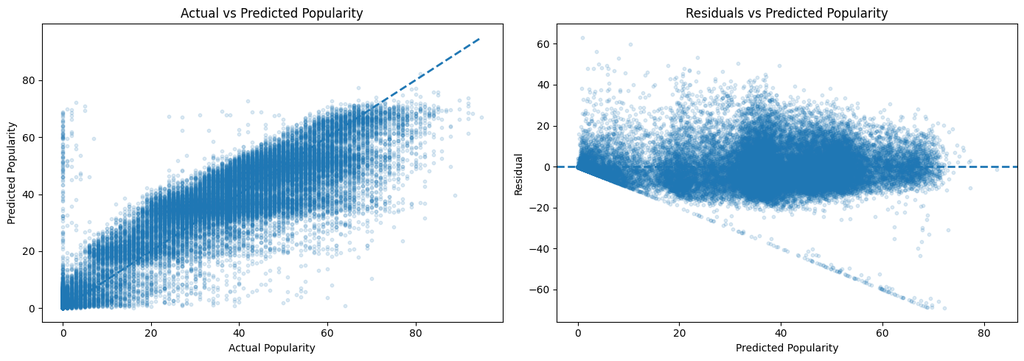

#### Diagnostic Interpretation

The diagnostic plots show that the selected Random Forest model captures the overall relationship between the predictors and song popularity, but important limitations remain.

In the actual-versus-predicted plot, predictions generally increase with observed popularity, confirming that the model captures a substantial portion of the overall pattern. However, predictions are compressed toward the middle of the popularity range. Very highly popular songs are frequently underpredicted, while some tracks with observed popularity equal to zero receive substantially positive predictions. The dense vertical concentration at zero is particularly relevant because approximately 16.3% of tracks in the dataset have a popularity score of zero.

The residual plot also reveals non-random structure rather than a uniform cloud around zero. Residual dispersion changes across the prediction range, and visible boundary patterns indicate that errors are constrained by the bounded 0–100 target scale. Large positive and negative residuals remain present, showing that the model has difficulty with some extreme observations.

Therefore, although the selected Random Forest model achieves strong overall test-set performance with an R² of 0.810, its errors are not completely random or constant across the prediction range. The diagnostics suggest regression toward moderate popularity values and reduced accuracy for extreme and zero-popularity observations. These limitations should be considered when interpreting the model's predictive performance.

### 7.8 Feature Importance

Feature importance is examined for the selected Random Forest model to identify which predictors contribute most to popularity predictions. This step helps interpret whether the model relies mainly on audio characteristics, release year, or a combination of both.

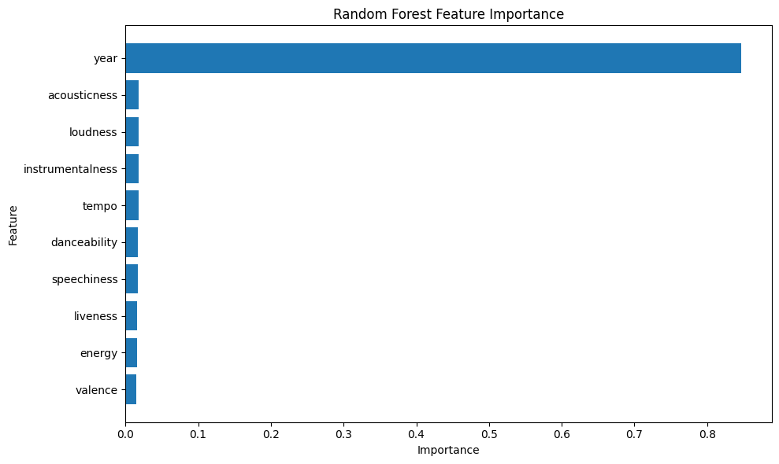

|  | Feature | Importance |
| --- | --- | --- |
| 0 | year | 0.847 |
| 1 | acousticness | 0.019 |
| 6 | loudness | 0.018 |
| 4 | instrumentalness | 0.018 |
| 8 | tempo | 0.018 |
| 2 | danceability | 0.017 |
| 7 | speechiness | 0.017 |
| 5 | liveness | 0.016 |
| 3 | energy | 0.016 |
| 9 | valence | 0.015 |

#### Feature Importance Interpretation

The feature-importance analysis shows that release year is by far the dominant predictor in the selected Random Forest model, accounting for approximately 84.7% of the model's total impurity-based importance. In contrast, each individual audio feature contributes a much smaller share, with importance values ranging from approximately 1.5% to 1.9%.

Among the audio characteristics, acousticness has the highest importance, followed closely by loudness, instrumentalness, and tempo. However, the differences among the audio features are relatively small compared with the overwhelming contribution of release year.

This result is consistent with the earlier exploratory and predictive analyses. Release year showed a strong association with popularity, and every model improved substantially when year was added to the audio features. Therefore, the selected model's high predictive performance should not be interpreted as evidence that audio characteristics alone explain song popularity. Instead, much of the predictive power reflects strong temporal structure in the dataset.

The dominance of release year may capture historical changes in music consumption, catalog composition, platform coverage, and the way popularity scores are represented across songs from different periods. In addition, Random Forest impurity-based importance is a model-specific measure and should not be interpreted as causal evidence. The results therefore indicate predictive importance rather than a causal effect of release year on popularity.

## 8. Discussion

This analysis investigated how well Spotify song popularity can be predicted from audio characteristics and release year. Across the exploratory and predictive stages, the results reveal a consistent pattern: audio features contain meaningful information about popularity, but temporal structure plays a substantially larger role.

The initial correlation analysis suggested relatively strong relationships between popularity and several audio characteristics. Energy and loudness showed positive associations with popularity, while acousticness and instrumentalness showed negative associations. However, these relationships changed considerably after accounting for release year. The year-adjusted correlations became much weaker, indicating that part of the apparent relationship between audio characteristics and popularity reflects broader historical changes in both musical characteristics and popularity scores.

This interpretation is reinforced by the predictive modeling results. The audio-only Linear Regression model achieved an R² of 0.444, demonstrating that audio characteristics alone contain meaningful predictive information. Non-linear ensemble models improved audio-only performance, with Random Forest reaching an R² of 0.585 and HistGradient Boosting reaching 0.581. These improvements suggest that relationships between musical characteristics and popularity are not purely linear.

The largest performance gains occurred when release year was added. Linear Regression improved to an R² of 0.759, while both Random Forest and HistGradient Boosting reached approximately 0.810. The selected Random Forest model achieved the lowest test-set errors, with an MAE of 6.695 and an RMSE of 9.534. Nevertheless, the feature-importance analysis showed that release year accounted for approximately 84.7% of the model's impurity-based importance, demonstrating that the model's strong predictive performance is driven primarily by temporal information rather than audio characteristics alone.

The diagnostic analysis also highlights important limitations. Predictions tend to be compressed toward moderate popularity values, with highly popular tracks often underpredicted and some zero-popularity tracks assigned substantially positive predictions. Residuals display non-random structure and changing dispersion across the prediction range. Therefore, the strong overall R² should not be interpreted as uniformly accurate prediction across all songs.

Overall, the findings suggest that song popularity in this dataset reflects a combination of musical characteristics and strong temporal structure. Audio features contribute predictive value, particularly through non-linear relationships, but release year is the dominant predictor. This result emphasizes the importance of controlling for temporal confounding when analyzing relationships between musical characteristics and platform-based popularity measures.

## 9. Limitations and Future Work

Several limitations should be considered when interpreting the results of this analysis.

First, the dataset is observational and does not support causal conclusions. Although release year and several audio characteristics are associated with popularity, the analysis cannot establish that these variables directly cause songs to become more or less popular.

Second, the popularity target is strongly structured by release year. The selected Random Forest model assigns approximately 84.7% of its impurity-based feature importance to year, and the predictive performance of all model families improves substantially when year is included. This suggests that the high test-set performance partly reflects temporal patterns in the dataset rather than musical characteristics alone.

Third, the analysis uses a random 80/20 train-test split. Because songs from similar historical periods can appear in both training and test sets, the reported metrics measure interpolation within a randomly held-out sample rather than genuine forecasting of popularity for future releases. A time-based validation strategy would provide a more demanding test of temporal generalization.

Fourth, approximately 16.3% of tracks have a popularity score of zero. These observations may represent genuinely unpopular tracks, catalog or measurement effects, or other platform-specific processes that cannot be distinguished using the available variables. The diagnostic plots indicate that the model has particular difficulty with this concentration of zero values.

Fifth, the predictor set is limited. Song popularity is influenced by many factors not represented in the analysis, including artist reputation, playlist placement, marketing exposure, social-media attention, genre, collaborations, label support, and broader cultural trends. Incorporating such variables could improve both predictive performance and substantive interpretation.

Finally, Random Forest impurity-based feature importance can be affected by feature characteristics and model structure. Future work could use permutation importance or SHAP-based explanations to provide a more robust assessment of predictor contributions.

Future research could extend this project by applying time-based validation, explicitly modeling zero-popularity tracks, incorporating artist- and genre-level information, tuning model hyperparameters through cross-validation, and evaluating additional algorithms. These extensions would help determine whether the observed predictive patterns generalize beyond the current randomly held-out test set.

## 10. Conclusion

This project investigated whether Spotify song popularity can be predicted from audio characteristics and release year using exploratory data analysis and machine learning. The analysis revealed a strong temporal structure in the dataset: popularity increases substantially for more recently released songs, with release year showing a correlation of approximately 0.86 with popularity.

The exploratory analysis also demonstrated why raw correlations between audio characteristics and popularity must be interpreted cautiously. Features such as energy, loudness, and acousticness initially showed moderate to strong associations with popularity. However, after adjusting for release year, these relationships became much weaker. This indicates that much of the apparent association between musical characteristics and popularity reflects broader historical changes in both music production and the dataset.

Predictive modeling confirmed these findings. The mean baseline produced an MAE of 18.56 and an RMSE of 21.88. Linear Regression using audio features alone improved performance to an R² of 0.444, while adding release year increased R² to 0.759. Non-linear ensemble methods performed better: the Random Forest model using audio features and year achieved the best overall performance, with an MAE of 6.695, RMSE of 9.534, and R² of 0.810. HistGradient Boosting produced nearly identical performance, with an R² of 0.810.

Model diagnostics showed that the selected Random Forest captures much of the overall structure in popularity but still exhibits systematic prediction errors, particularly around the large concentration of zero-popularity tracks and at the extremes of the target distribution. Feature importance further demonstrated the dominance of release year, which accounted for approximately 84.7% of the model's impurity-based importance.

Overall, the results suggest that Spotify popularity is predictable to a substantial degree within this dataset, but prediction is driven primarily by temporal structure rather than audio characteristics alone. Therefore, the project demonstrates both the value of machine learning for popularity prediction and the importance of careful interpretation when strong historical patterns are present in observational data.